# Correlations_with_published_data_forGithub

## Correlations of the RNAseq and TMT MS data with previously published data

This Python notebook includes the code that was used to correlate the RNA and protein remodeling during DNA limitation with previously published datasets in the literature.

**Publication:** Genome concentration limits cell growth and modulates proteome composition in *Escherichia coli*

**Authors:** Jarno Mäkelä$^{1,2,3,†}$, Alexandros Papagiannakis$^{1,2,†}$, Wei-Hsiang Lin$^{1,2,\&}$, Michael C. Lanz$^{4,5,\&}$, Skye Glenn$^{2,4}$, Matthew Swaffer$^{4,¶}$, Georgi K. Marinov$^{6}$, Jan M. Skotheim$^{4,5}$, Christine Jacobs-Wagner$^{1,2,4,*}$

**Affiliations and contributions:**  
$^{1}$Howard Hughes Medical Institute, Stanford University, Stanford, CA 94305, USA

$^{2}$Sarafan Chemistry, Engineering, and Medicine for Human Health Institute, Stanford University, Stanford, CA 94305, USA

$^{3}$Institute of Biotechnology, Helsinki Institute of Life Science, University of Helsinki, Helsinki, Finland

$^{4}$Department of Biology, Stanford University, Stanford, CA 94305, USA

$^{5}$Chan Zuckerberg Biohub, Stanford, CA 94305, USA

$^{6}$Department of Genetics, Stanford University, Stanford, CA 94305, USA

$^{¶}$Current address: Wellcome Centre for Cell Biology, University of Edinburgh, Edinburgh, EH9 3BF, UK

$^{†}$These authors contributed equally to this work.

$^{\&}$These authors contributed equally to this work.

*For correspondence: jacobs-wagner@stanford.edu

**Developer:**  
Developed by Alexandros Papagiannakis (alexpapa@staford.edu), Stanford University / Howard Hughes Medical Institute, Christine Jacobs-Wagner lab 2024.

**TMT MS data generated** by Jarno Mäkelä and Michael C. Lanz

**RNAseq data generated** by Skye Glenn, Matthew Swaffer and Georgi K. Marinov

**Data were used from the following publications:**

Balakrishnan et al. (2022) - PMID 36480614 (mRNA relative abundances and degradation rates)

Gerdes et al. (2003) - PMID 13129938 (essential genes)

Goodall et al. (2018) - PMID 29463657 (essential genes)

Hashimoto et al. (2005) - PMID 15612923 (essential genes)

```python
import pandas as pd
import numpy as np
import matplotlib.pyplot as plt
import seaborn as sns
import scipy as sp
from scipy.stats import spearmanr, gaussian_kde
import pickle
import skimage
import os
import matplotlib
from sklearn.decomposition import PCA
import warnings
warnings.filterwarnings("ignore")
import matplotlib
```

```python
# Loading our data
prot_data_path =r"...\Dataset_1.xlsx"
rna_data_path  = r"...\Dataset_2.txt"

prot_data_index = pd.read_excel(prot_data_path,
                         sheet_name = 'Index')

prot_data_main = pd.read_excel(prot_data_path,
                         sheet_name = 'Main')

prot_data_exp1 = pd.read_excel(prot_data_path,
                         sheet_name = 'Exp #1')

prot_data_exp2 = pd.read_excel(prot_data_path,
                         sheet_name = 'Exp #2')

prot_data_misc = pd.read_excel(prot_data_path,
                         sheet_name = 'Misc')

rna_data = pd.read_table(rna_data_path)

save_path_dir = "None"
```

```python
# Loading previously published data

#  Balakrishnan et al. (2002) - PMID 36480614
rates_df = pd.read_excel(r"...\science.abk2066_table_s6.xlsx", sheet_name = 'reference condition')

# Gerdes et al. (2003) - PMID 13129938 (essential genes)
ess_df = pd.read_excel(r"...\table_s2_excel.xlsx")
ess_df['Gerdes etal'].replace('N*', 'N', inplace=True)
ess_df['PEC'].replace('E*', 'E', inplace=True)
print(ess_df.columns)

# Goodall et al. (2018) - PMID 29463657 (essential genes)
ess_2_df = pd.read_excel(r"...\Copy of mbo001183726st1.xlsx")
gene_id_dict = pd.Series(rna_data.gene_ID.values, index=rna_data.gene_name).to_dict()
ess_2_df['gene_ID'] = ess_2_df['Gene'].map(gene_id_dict)
print(ess_2_df.columns)

# Hashimoto et al. (2005) - PMID 15612923 (essential genes)
ess_3_df = pd.read_excel(r"...\PEC_essentials\PEC.xls")
gene_id_list = []
for ess_index, ess_row in ess_3_df.iterrows():
    i = 0
    for b_n in rna_data.gene_ID:
        if b_n in str(ess_row['Alternative Name']):
            gene_id_list.append(b_n)
            i+=1
    if i == 0:
        print(str(ess_row['Alternative Name']))
        gene_id_list.append(np.nan)
    elif i > 1:
        break
ess_3_df['gene_ID'] = gene_id_list
print(ess_3_df.columns)
```

```
Index(['Subset', 'In subset', 'ERGO ID', 'b-number', 'gene name',
       'Gerdes etal', 'PEC', 'Blattner etal', 'SWISPROT'],
      dtype='object')
Index(['Gene', 'Insertion Index Score', 'Log Likelihood Ratio', 'Essential',
       'Non-essential', 'Unclear', 'gene_ID'],
      dtype='object')
b0455,ECK0449,JWR0009
argW,b0536,dnaY,ECK0529,fimU,JWR0010,pin
b0672,ECK0660,feeB,JWR0016,o50
b0971,divE,ECK0962,JWR0026
b1085,ECK1070,JW5154,o124
b1909,ECK1908,JWR0033
b1910,ECK1909,JWR0034
b2695,ECK2690,JWR0061,supD
b3123,ECK3111,JWR0070
b3174,ECK3163,JWR0072
b3761,ECK3755,JWR0087,su7,su8,su9,supU,supV
b3796,ECK3789,JWR0088
b3797,ECK3790,JWR0089
b3799,ECK3792,JWR0091,proU
b3976,ECK3967,JWR0103
b3978,ECK3969,JWR0105,sumA,sup15B,supA36
Index(['ORF ID', 'Gene Name', 'Class(1:essential 2:nonessential 3:unknown)',
       'Alternative Name', 'Map Position', 'Start(BP)', 'End(BP)', 'Length',
       'Direction(0:+ 1:-)', 'Ncbi ID', 'Product', 'Swissprot Acc No', 'Note',
       'gene_ID'],
      dtype='object')
```

```python
gerdes_essential = ess_df[(ess_df['Gerdes etal']=='E')]['b-number'].tolist()
print(len(gerdes_essential), 'essential genes for Gerdes etal 2003')
# pec_essential = ess_df[(ess_df['PEC']=='E')]['b-number'].tolist()
pec_essential = ess_3_df[~ess_3_df.gene_ID.isnull()].gene_ID.tolist()
print(len(pec_essential), 'essential genes for Hashimoto etal 2005')
goodall_essential = ess_2_df[(ess_2_df['Essential']==True)]['gene_ID'].tolist()
print(len(goodall_essential), 'essential genes for Goodall etal 2018')
# inter_essential = list(set(gerdes_essential)&set(pec_essential)&set(goodall_essential))
inter_essential = list(set(gerdes_essential)&set(goodall_essential))
# inter_essential = list(set(pec_essential)&set(goodall_essential))
```

```
622 essential genes for Gerdes etal 2003
286 essential genes for Hashimoto etal 2005
358 essential genes for Goodall etal 2018
```

```python
def get_protein_slope_dict(dataframe):

    onen_dict = pd.Series(dataframe['Protien Slope (1-N)'].values, index=dataframe.Uniprot).to_dict()
    mltn_dict = pd.Series(dataframe['Protien Slope (multi-N)'].values, index=dataframe.Uniprot).to_dict()

    return onen_dict, mltn_dict

def assemgle_protein_slope_dataframe(dataframe_exp1, dataframe_exp2, rna_df):

    gene_name_to_id_dict = pd.Series(rna_df.gene_ID.values, index=rna_df.gene_name).to_dict()
    uniprot_to_gene_name_dict = pd.Series(dataframe_exp1['Gene name (primary )'].values, index=dataframe_exp1.Uniprot).to_dict()

    onen_dict_exp1, mltn_dict_exp1 = get_protein_slope_dict(dataframe_exp1)
    onen_dict_exp2, mltn_dict_exp2 = get_protein_slope_dict(dataframe_exp2)

    slope_df = pd.DataFrame()
    slope_df['Uniprot'] = np.unique(list(onen_dict_exp1.keys())+list(onen_dict_exp2.keys()))
    slope_df['slope_1N_exp1'] = slope_df.Uniprot.map(onen_dict_exp1)
    slope_df['slope_1N_exp2'] = slope_df.Uniprot.map(onen_dict_exp2)
    slope_df['slope_mltN_exp1'] = slope_df.Uniprot.map(mltn_dict_exp1)
    slope_df['slope_mltN_exp2'] = slope_df.Uniprot.map(mltn_dict_exp2)
    slope_df['gene_name'] = slope_df.Uniprot.map(uniprot_to_gene_name_dict)
    slope_df['gene_ID'] = slope_df.gene_name.map(gene_name_to_id_dict)

    return slope_df

def get_ion_intensity_and_ori_distance(misc_df, slope_df):

    ori_dict = pd.Series(misc_df['Circular distance from oriC'].values, index = misc_df['Entry']).to_dict()
    ion_dict = pd.Series(misc_df['Summed ion intensity / Length'].values, index = misc_df['Entry']).to_dict()

    slope_df['ori_distance'] = slope_df.Uniprot.map(ori_dict)
    slope_df['ion_intensity'] = slope_df.Uniprot.map(ion_dict)
    slope_df['mean_slope_1N'] = (slope_df['slope_1N_exp1']+slope_df['slope_1N_exp2'])/2
    slope_df['mean_slope_mltN'] = (slope_df['slope_mltN_exp1']+slope_df['slope_mltN_exp2'])/2

    return slope_df


def get_rates(rates_df, slope_df,
              prot_misc_df, rna_df):

    protein_conc_dict = pd.Series(rates_df['protein concentration [Pi] (1/µm3)'].values, index = rates_df['locus']).to_dict()
    rna_conc_dict = pd.Series(rates_df['mRNA concentration [mRi] (1/µm3)'].values, index = rates_df['locus']).to_dict()
    transl_init_dict = pd.Series(rates_df['translation inititation rate αpi (1/min)'].values, index = rates_df['locus']).to_dict()
    rna_degr_dict = pd.Series(rates_df['mRNA degradation rate, δi (1/min)'].values, index = rates_df['locus']).to_dict()
    transc_init_dict = pd.Series(rates_df['transcriptional initiation rate, αmi (1/min)'].values, index = rates_df['locus']).to_dict()
    promoter_on_dict = pd.Series(rates_df['promoter on-rate, ki (µm3/min)'].values, index = rates_df['locus']).to_dict()

    rna_df['protein_conc'] = rna_df.gene_ID.map(protein_conc_dict)
    rna_df['rna_conc'] = rna_df.gene_ID.map(rna_conc_dict)
    rna_df['translation_init'] = rna_df.gene_ID.map(transl_init_dict)
    rna_df['transcription_init'] = rna_df.gene_ID.map(transc_init_dict)
    rna_df['rna_degradation'] = rna_df.gene_ID.map(rna_degr_dict)
    rna_df['promoter_on'] = rna_df.gene_ID.map(promoter_on_dict)

    onen_slope_dict = pd.Series(slope_df.mean_slope_1N.values, slope_df.gene_ID).to_dict()
    mltn_slope_dict = pd.Series(slope_df.mean_slope_mltN.values, slope_df.gene_ID).to_dict()
    intensity_dict_prot = pd.Series(slope_df.ion_intensity.values, slope_df.gene_ID).to_dict()
    intensity_dict = pd.Series(prot_misc_df['Summed ion intensity'].values, index=prot_misc_df['Gene name']).to_dict()
    intensity_length_dict = pd.Series(prot_misc_df['Summed ion intensity / Length'].values, index=prot_misc_df['Gene name']).to_dict()
    ori_dict = pd.Series(prot_misc_df['Circular distance from oriC'].values, index=prot_misc_df['Gene name']).to_dict()

    rna_df['1N_protein_slope'] = rna_df.gene_ID.map(onen_slope_dict)
    rna_df['mltN_protein_slope'] = rna_df.gene_ID.map(mltn_slope_dict)
    rna_df['protein_ion_intensity'] = rna_df.gene_ID.map(intensity_dict_prot)
    rna_df['summed_ion_intensity'] = rna_df.gene_name.map(intensity_dict)
    rna_df['summed_ion_intensity_per_length'] = rna_df.gene_name.map(intensity_length_dict)
    rna_df['circular_ori_distance'] = rna_df.gene_name.map(ori_dict)
    rna_df['gene_length'] = rna_df.summed_ion_intensity/rna_df.summed_ion_intensity_per_length

    return rna_df


def density_scatter(x,y):
    xy = np.vstack([x,y])
    z = gaussian_kde(xy)(xy)
    return z
```

```python
protein_slope_df = assemgle_protein_slope_dataframe(prot_data_exp1, prot_data_exp2, rna_data)
protein_slope_df = get_ion_intensity_and_ori_distance(prot_data_misc, protein_slope_df)
rna_data = get_rates(rates_df, protein_slope_df, prot_data_misc, rna_data)
```

### Balakrishnan et al (2022) - Correlation with protein concentration, mRNA concentration, transcription initiation rate and mRNA degradation rate

```python
def plot_concentration_comparisons_with_literature(rna_data):

    plt.figure(figsize=(12,4))
    gs = matplotlib.gridspec.GridSpec(1, 5, height_ratios=[1], width_ratios=[1,0.1,0.5,1,0.1])
    gss = [plt.subplot(gs[0,0]),
           plt.subplot(gs[0,1]),
            plt.subplot(gs[0,3]),
            plt.subplot(gs[0,4])]
    one_axis = gss[0]
    cbar_one_axis = gss[1]
    two_axis = gss[2]
    cbar_two_axis = gss[3]

    plot_df = rna_data[rna_data['summed_ion_intensity_per_length']>0]
    spear_df = pd.DataFrame()
    spear_df['x'] = plot_df['summed_ion_intensity_per_length'].astype(float)
    spear_df['y'] = plot_df.protein_conc.astype(float)
    spear_df = spear_df.dropna()
    spear_df['z'] = density_scatter(np.log10(spear_df.x), np.log10(spear_df.y))
    print(plot_df.shape)

    im1 = one_axis.scatter(spear_df.x, spear_df.y, c=spear_df.z, cmap='cividis', s=2)
    one_axis.set_yscale('log')
    one_axis.set_xscale('log')
    cbar_one = plt.colorbar(im1, cax=cbar_one_axis)
    cbar_one.set_label('Density', rotation=90, fontsize=14, fontweight='bold')
    print(spearmanr(spear_df.x, spear_df.y))
    one_axis.set_xlabel('Summed ion intensity / gene Length', fontsize=14, fontweight='bold')
    one_axis.set_ylabel('Protein concentration (1/um$^3$)\nBalakrishnan $et al$, 2022', fontsize=14, fontweight='bold')


    plot_df = rna_data[rna_data['TPM_60min']>0]
    spear_df = pd.DataFrame()
    spear_df['x'] = plot_df['TPM_60min'].astype(float)
    spear_df['y'] = plot_df.rna_conc.astype(float)
    spear_df = spear_df.dropna()
    spear_df['z'] = density_scatter(np.log10(spear_df.x), np.log10(spear_df.y))
    print(plot_df.shape)


    im2 = two_axis.scatter(spear_df.x, spear_df.y, c=spear_df.z, cmap='cividis', s=2)
    two_axis.set_yscale('log')
    two_axis.set_xscale('log')
    cbar_two = plt.colorbar(im2, cax=cbar_two_axis)
    cbar_two.set_label('Density', rotation=90, fontsize=14, fontweight='bold')
    print(spearmanr(spear_df.x, spear_df.y))
    two_axis.set_xlabel('Transcripts per million\n(60min after induction)', fontsize=14, fontweight='bold')
    two_axis.set_ylabel('mRNA concentration (1/um$^3$)\nBalakrishnan $et al$, 2022', fontsize=14, fontweight='bold')
```

```
(2200, 23)
SpearmanrResult(correlation=0.7431112281883404, pvalue=1.243910081446719e-296)
(3446, 23)
SpearmanrResult(correlation=0.7618206714252065, pvalue=0.0)
```

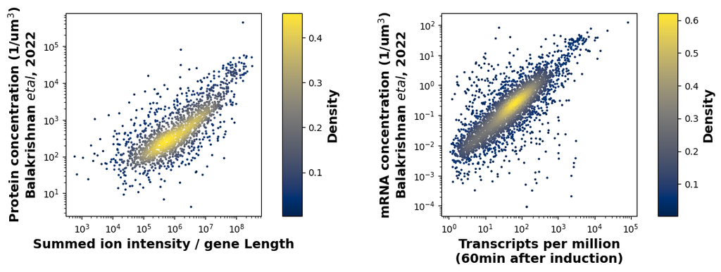

```python
plot_concentration_comparisons_with_literature(rna_data)
```

```python
def correlations_with_rate_statistics(rna_data):

    min_val, max_val = 0.15,0.9
    n = 10
    orig_cmap = plt.cm.binary
    colors = orig_cmap(np.linspace(min_val, max_val, n))
    short_cmap = matplotlib.colors.LinearSegmentedColormap.from_list("mycmap", colors)


    cmap_ = short_cmap
#     cmap_ = 'cividis'
    markercolor_ = 'orange'

    markersize_=15

    plt.figure(figsize=(15,12))
    gs = matplotlib.gridspec.GridSpec(2, 6, height_ratios=[1,1], width_ratios=[0.8,0.1,0.5]*2)
    gss = [plt.subplot(gs[0,0]),
           plt.subplot(gs[0,3]),
            plt.subplot(gs[1,0]),
              plt.subplot(gs[1,3])]

    # Image 1
    plot_df = rna_data.copy()
    spear_df = pd.DataFrame()
    spear_df['x'] = plot_df['transcription_init'].astype(float)
    spear_df['y'] = plot_df.RNA_slope.astype(float)
    spear_df = spear_df[spear_df.x>0]
    spear_df = spear_df.dropna()
    spear_df['z'] = density_scatter(np.log10(spear_df.x), spear_df.y)

    spear_df['log_x'] = np.log10(spear_df.x)
    spear_df['x_bin'] = pd.qcut(spear_df.x, 9)
    print(spear_df.x_bin.value_counts())
    mean_df = spear_df.groupby(spear_df.x_bin).mean()
    err_df = spear_df.groupby(spear_df.x_bin).sem()
    print(spear_df.shape)
    print(spearmanr(spear_df.x, spear_df.y))
    im1 = gss[0].scatter(spear_df.x, spear_df.y, c=spear_df.z, cmap=cmap_, s=markersize_)
    gss[0].errorbar(mean_df.x, mean_df.y, yerr=err_df.y,
            marker='o', markersize=10, markerfacecolor='none',ls='none', color=markercolor_)
    gss[0].set_xscale('log')
    cbar_one = plt.colorbar(im1, cax=plt.subplot(gs[0,1]))
    cbar_one.set_label('Density', rotation=90, fontsize=14, fontweight='bold')
    gss[0].set_xlabel('Transcription initiation rate (1/min)\nBalakrishnan $et al$, 2022', fontsize=14, fontweight='bold')
    gss[0].set_ylabel('RNA slope - 1N cells', fontsize=14, fontweight='bold')
    gss[0].axhline(0, color='black', linewidth=0.5)
    gss[0].set_ylim(-2,2)

    # Image 3
    plot_df = rna_data.copy()
    spear_df = pd.DataFrame()
    spear_df['x'] = plot_df['rna_degradation'].astype(float)
    spear_df['y'] = plot_df.RNA_slope.astype(float)
    spear_df = spear_df[spear_df.x>0]
    spear_df = spear_df.dropna()
    spear_df['z'] = density_scatter(np.log10(spear_df.x), spear_df.y)

    spear_df['log_x'] = np.log10(spear_df.x)
    spear_df['x_bin'] = pd.qcut(spear_df.x, 9)
    print(spear_df.x_bin.value_counts())
    print(spear_df.shape)
    mean_df = spear_df.groupby(spear_df.x_bin).mean()
    err_df = spear_df.groupby(spear_df.x_bin).sem()

    print(spearmanr(spear_df.x, spear_df.y))
    im3 = gss[1].scatter(spear_df.x, spear_df.y, c=spear_df.z, cmap=cmap_, s=markersize_)
    gss[1].errorbar(mean_df.x, mean_df.y, yerr=err_df.y,
            marker='o', markersize=10, markerfacecolor='none',ls='none', color=markercolor_)
    gss[1].set_xscale('log')
    cbar_three = plt.colorbar(im3, cax=plt.subplot(gs[0,4]))
    cbar_three.set_label('Density', rotation=90, fontsize=14, fontweight='bold')
    gss[1].set_xlabel('mRNA degradation rate (1/min)\nBalakrishnan $et al$, 2022', fontsize=14, fontweight='bold')
    gss[1].set_ylabel('RNA slope - 1N cells', fontsize=14, fontweight='bold')
    gss[1].axhline(0, color='black', linewidth=0.5)
    gss[1].set_ylim(-2,2)

    print('truncated spearman, x > 0.7 1/min')
    spear_df = spear_df[spear_df.x>=0.7]
    print(spearmanr(spear_df.x, spear_df.y))


    # Image 5
    plot_df = rna_data.copy()
    spear_df = pd.DataFrame()
    spear_df['x'] = plot_df['transcription_init'].astype(float)
    spear_df['y'] = plot_df.mean_protein_slope_1N.astype(float)
    spear_df = spear_df[spear_df.x>0]
    spear_df = spear_df.dropna()
    spear_df['z'] = density_scatter(np.log10(spear_df.x), spear_df.y)

    spear_df['log_x'] = np.log10(spear_df.x)
    spear_df['x_bin'] = pd.qcut(spear_df.x, 9)
    print(spear_df.shape)
    print(spear_df.x_bin.value_counts())
    mean_df = spear_df.groupby(spear_df.x_bin).mean()
    err_df = spear_df.groupby(spear_df.x_bin).sem()

    print(spearmanr(spear_df.x, spear_df.y))
    im5 = gss[2].scatter(spear_df.x, spear_df.y, c=spear_df.z, cmap=cmap_, s=markersize_)
    gss[2].errorbar(mean_df.x, mean_df.y, yerr=err_df.y,
            marker='o', markersize=10, markerfacecolor='none',ls='none', color=markercolor_)
    gss[2].set_xscale('log')
    cbar_five = plt.colorbar(im5, cax=plt.subplot(gs[1,1]))
    cbar_five.set_label('Density', rotation=90, fontsize=14, fontweight='bold')
    gss[2].set_xlabel('Transcription initiation rate (1/min)\nBalakrishnan $et al$, 2022', fontsize=14, fontweight='bold')
    gss[2].set_ylabel('Protein slope - 1N cells', fontsize=14, fontweight='bold')
    gss[2].axhline(0, color='black', linewidth=0.5)
    gss[2].set_ylim(-1.25,1.25)

    # Image 7
    plot_df = rna_data.copy()
    spear_df = pd.DataFrame()
    spear_df['x'] = plot_df['rna_degradation'].astype(float)
    spear_df['y'] = plot_df.mean_protein_slope_1N.astype(float)
    spear_df = spear_df[spear_df.x>0]
    spear_df = spear_df.dropna()
    spear_df['z'] = density_scatter(np.log10(spear_df.x), spear_df.y)

    spear_df['log_x'] = np.log10(spear_df.x)
    spear_df['x_bin'] = pd.qcut(spear_df.x, 9)
    print(spear_df.shape)
    print(spear_df.x_bin.value_counts())
    mean_df = spear_df.groupby(spear_df.x_bin).mean()
    err_df = spear_df.groupby(spear_df.x_bin).sem()

    print(spearmanr(spear_df.x, spear_df.y))
    im7 = gss[3].scatter(spear_df.x, spear_df.y, c=spear_df.z, cmap=cmap_, s=markersize_)
    gss[3].errorbar(mean_df.x, mean_df.y, yerr=err_df.y,
                marker='o', markersize=10, markerfacecolor='none',ls='none', color=markercolor_)
    gss[3].set_xscale('log')
    cbar_seven = plt.colorbar(im7, cax=plt.subplot(gs[1,4]))
    cbar_seven.set_label('Density', rotation=90, fontsize=14, fontweight='bold')
    gss[3].set_xlabel('mRNA degradation rate (1/min)\nBalakrishnan $et al$, 2022', fontsize=14, fontweight='bold')
    gss[3].set_ylabel('Protein slope - 1N cells', fontsize=14, fontweight='bold')
    gss[3].axhline(0, color='black', linewidth=0.5)
    gss[3].set_ylim(-1.25,1.25)
    print('truncated spearman, x > 0.7 1/min')
    spear_df = spear_df[spear_df.x>=0.7]
    print(spearmanr(spear_df.x, spear_df.y))

    plt.show()
```

```
(-0.000892, 0.0357]    287
(0.189, 0.272]         287
(1.326, 102.419]       287
(0.0357, 0.0743]       286
(0.0743, 0.12]         286
(0.12, 0.189]          286
(0.272, 0.407]         286
(0.407, 0.65]          286
(0.65, 1.326]          286
Name: x_bin, dtype: int64
(2577, 5)
SpearmanrResult(correlation=0.09242609337609105, pvalue=2.605196451136005e-06)
(0.0675, 0.339]    286
(0.501, 0.678]     286
(0.841, 1.009]     286
(1.179, 1.36]      286
(1.557, 2.449]     286
(0.339, 0.501]     285
(0.678, 0.841]     285
(1.009, 1.179]     285
(1.36, 1.557]      285
Name: x_bin, dtype: int64
(2570, 5)
SpearmanrResult(correlation=-0.1506151289478768, pvalue=1.6468791521387475e-14)
truncated spearman, x > 0.7 1/min
SpearmanrResult(correlation=-0.18019743761711535, pvalue=1.2393806172949832e-13)
(2084, 5)
(-0.000892, 0.045]    232
(0.0935, 0.153]       232
(0.228, 0.315]        232
(0.458, 0.74]         232
(1.454, 102.419]      232
(0.045, 0.0935]       231
(0.153, 0.228]        231
(0.315, 0.458]        231
(0.74, 1.454]         231
Name: x_bin, dtype: int64
SpearmanrResult(correlation=0.06830899663177249, pvalue=0.0018076658362481354)
(2078, 5)
(0.0801, 0.327]    231
(0.327, 0.466]     231
(0.466, 0.634]     231
(0.634, 0.775]     231
(0.939, 1.112]     231
(1.112, 1.285]     231
(1.285, 1.501]     231
(1.501, 2.449]     231
(0.775, 0.939]     230
Name: x_bin, dtype: int64
SpearmanrResult(correlation=-0.18396520516721465, pvalue=2.832629549832181e-17)
truncated spearman, x > 0.7 1/min
SpearmanrResult(correlation=-0.21697796565685487, pvalue=4.299573403910878e-15)
```

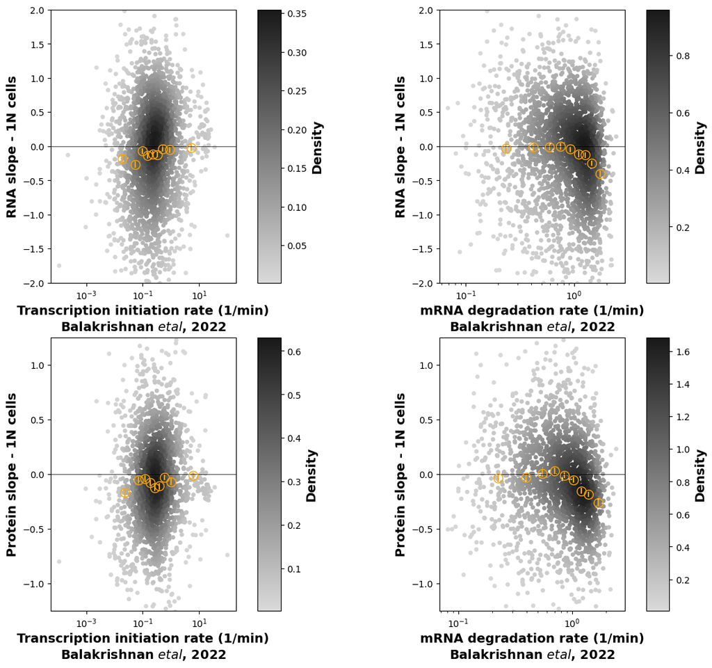

```python
correlations_with_rate_statistics(rna_data)
```

### Comparative analysis of essential vs non-essential genes

```
554
2892
```

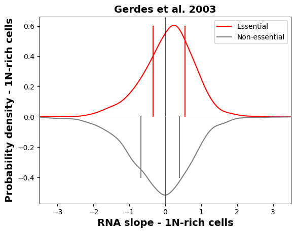

```
MannwhitneyuResult(statistic=659189.0, pvalue=3.734048004917964e-11)
334
3112
```

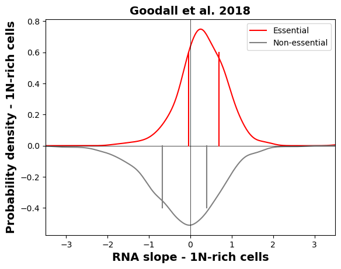

```
MannwhitneyuResult(statistic=336282.0, pvalue=2.533162672098998e-26)
286
3160
```

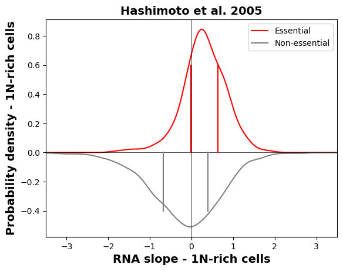

```
MannwhitneyuResult(statistic=289703.0, pvalue=7.856141490323598e-24)
```

```python
ess_rna_df = rna_data[rna_data.gene_ID.isin(gerdes_essential)]
non_rna_df = rna_data[~rna_data.gene_ID.isin(gerdes_essential)]

print(ess_rna_df.shape[0])
print(non_rna_df.shape[0])
ess_kde = sp.stats.gaussian_kde(ess_rna_df.RNA_slope, bw_method='scott')
non_ess_kde = sp.stats.gaussian_kde(non_rna_df.RNA_slope, bw_method='scott')
eval_points = np.arange(-3.5, 3.51, 0.01)
plt.title('Gerdes et al. 2003', fontweight='bold', fontsize=14)
plt.plot(eval_points, ess_kde.pdf(eval_points), color='red', label='Essential')
plt.plot(eval_points, -non_ess_kde.pdf(eval_points), color='gray', label='Non-essential')
plt.axhline(0, linewidth=0.5, color='black')
plt.axvline(0, linewidth=0.5, color='black')
plt.plot([np.quantile(ess_rna_df.RNA_slope, 0.25), np.quantile(ess_rna_df.RNA_slope, 0.25)], [0,0.6], color='red')
plt.plot([np.quantile(ess_rna_df.RNA_slope, 0.75), np.quantile(ess_rna_df.RNA_slope, 0.75)], [0,0.6], color='red')
plt.plot([np.quantile(non_rna_df.RNA_slope, 0.25), np.quantile(non_rna_df.RNA_slope, 0.25)], [-0.4, 0], color='gray')
plt.plot([np.quantile(non_rna_df.RNA_slope, 0.75), np.quantile(non_rna_df.RNA_slope, 0.75)], [-0.4, 0], color='gray')
plt.xlim(-3.5, 3.5)
plt.legend()
plt.xlabel('RNA slope - 1N-rich cells', fontweight='bold', fontsize=14)
plt.ylabel('Probability density - 1N-rich cells', fontweight='bold', fontsize=14)
plt.show()

print(sp.stats.mannwhitneyu(
    non_rna_df.RNA_slope,
    ess_rna_df.RNA_slope
))


ess_rna_df = rna_data[rna_data.gene_ID.isin(goodall_essential)]
non_rna_df = rna_data[~rna_data.gene_ID.isin(goodall_essential)]
print(ess_rna_df.shape[0])
print(non_rna_df.shape[0])
ess_kde = sp.stats.gaussian_kde(ess_rna_df.RNA_slope, bw_method='scott')
non_ess_kde = sp.stats.gaussian_kde(non_rna_df.RNA_slope, bw_method='scott')
eval_points = np.arange(-3.5, 3.51, 0.01)
plt.title('Goodall et al. 2018', fontweight='bold', fontsize=14)
plt.plot(eval_points, ess_kde.pdf(eval_points), color='red', label='Essential')
plt.plot(eval_points, -non_ess_kde.pdf(eval_points), color='gray', label='Non-essential')
plt.axhline(0, linewidth=0.5, color='black')
plt.axvline(0, linewidth=0.5, color='black')
plt.plot([np.quantile(ess_rna_df.RNA_slope, 0.25), np.quantile(ess_rna_df.RNA_slope, 0.25)], [0,0.6], color='red')
plt.plot([np.quantile(ess_rna_df.RNA_slope, 0.75), np.quantile(ess_rna_df.RNA_slope, 0.75)], [0,0.6], color='red')
plt.plot([np.quantile(non_rna_df.RNA_slope, 0.25), np.quantile(non_rna_df.RNA_slope, 0.25)], [-0.4, 0], color='gray')
plt.plot([np.quantile(non_rna_df.RNA_slope, 0.75), np.quantile(non_rna_df.RNA_slope, 0.75)], [-0.4, 0], color='gray')
plt.xlim(-3.5, 3.5)
plt.legend()
plt.xlabel('RNA slope - 1N-rich cells', fontweight='bold', fontsize=14)
plt.ylabel('Probability density - 1N-rich cells', fontweight='bold', fontsize=14)
plt.show()

print(sp.stats.mannwhitneyu(
    non_rna_df.RNA_slope,
    ess_rna_df.RNA_slope
))


ess_rna_df = rna_data[rna_data.gene_ID.isin(pec_essential)]
non_rna_df = rna_data[~rna_data.gene_ID.isin(pec_essential)]
print(ess_rna_df.shape[0])
print(non_rna_df.shape[0])
ess_kde = sp.stats.gaussian_kde(ess_rna_df.RNA_slope, bw_method='scott')
non_ess_kde = sp.stats.gaussian_kde(non_rna_df.RNA_slope, bw_method='scott')
eval_points = np.arange(-3.5, 3.51, 0.01)
plt.title('Hashimoto et al. 2005', fontweight='bold', fontsize=14)
plt.plot(eval_points, ess_kde.pdf(eval_points), color='red', label='Essential')
plt.plot(eval_points, -non_ess_kde.pdf(eval_points), color='gray', label='Non-essential')
plt.axhline(0, linewidth=0.5, color='black')
plt.axvline(0, linewidth=0.5, color='black')
plt.plot([np.quantile(ess_rna_df.RNA_slope, 0.25), np.quantile(ess_rna_df.RNA_slope, 0.25)], [0,0.6], color='red')
plt.plot([np.quantile(ess_rna_df.RNA_slope, 0.75), np.quantile(ess_rna_df.RNA_slope, 0.75)], [0,0.6], color='red')
plt.plot([np.quantile(non_rna_df.RNA_slope, 0.25), np.quantile(non_rna_df.RNA_slope, 0.25)], [-0.4, 0], color='gray')
plt.plot([np.quantile(non_rna_df.RNA_slope, 0.75), np.quantile(non_rna_df.RNA_slope, 0.75)], [-0.4, 0], color='gray')
plt.xlim(-3.5, 3.5)
plt.legend()
plt.xlabel('RNA slope - 1N-rich cells', fontweight='bold', fontsize=14)
plt.ylabel('Probability density - 1N-rich cells', fontweight='bold', fontsize=14)
plt.show()

print(sp.stats.mannwhitneyu(
    non_rna_df.RNA_slope,
    ess_rna_df.RNA_slope
))
```

```
328 2242
MannwhitneyuResult(statistic=349079.0, pvalue=0.13820592079892058)
```

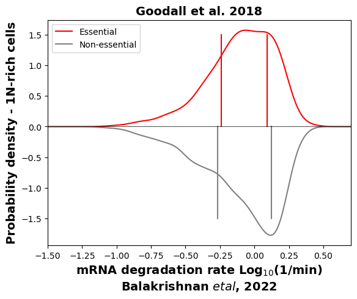

```
286 2284
MannwhitneyuResult(statistic=324412.0, pvalue=0.8525053580123166)
```

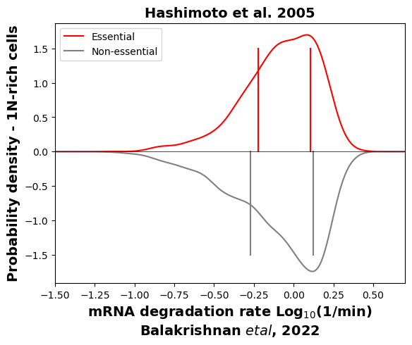

```
464 2106
MannwhitneyuResult(statistic=459428.0, pvalue=0.04384827739691148)
```

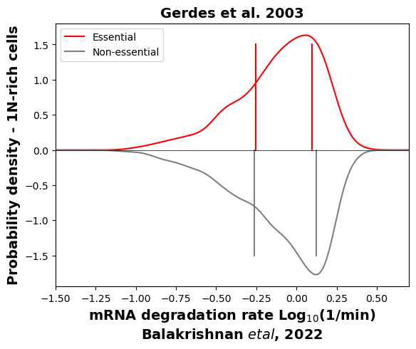

```python
esential_group  = goodall_essential
ess_deg_df = rna_data[rna_data.gene_ID.isin(esential_group)][['rna_degradation']].dropna()
ess_deg_df = ess_deg_df[ess_deg_df.rna_degradation.astype(float)>0]
non_deg_df = rna_data[~rna_data.gene_ID.isin(esential_group)][['rna_degradation']].dropna()
non_deg_df = non_deg_df[non_deg_df.rna_degradation.astype(float)>0]
ess_log_deg= np.log10(ess_deg_df.rna_degradation.astype(float)).to_list()
non_log_deg= np.log10(non_deg_df.rna_degradation.astype(float)).to_list()
print(len(ess_log_deg), len(non_log_deg))
ess_kde = sp.stats.gaussian_kde(ess_log_deg, bw_method='scott')
non_ess_kde = sp.stats.gaussian_kde(non_log_deg, bw_method='scott')
eval_points = np.arange(-2,1,0.001)
plt.title('Goodall et al. 2018', fontweight='bold', fontsize=14)
plt.plot(eval_points, ess_kde.pdf(eval_points), color='red', label='Essential')
plt.plot(eval_points, -non_ess_kde.pdf(eval_points), color='gray', label='Non-essential')
# plt.axhline(0, linewidth=0.5, color='black')
# plt.axvline(0, linewidth=0.5, color='black')
plt.plot([np.quantile(ess_log_deg, 0.25), np.quantile(ess_log_deg, 0.25)], [0,1.5], color='red')
plt.plot([np.quantile(ess_log_deg, 0.75), np.quantile(ess_log_deg, 0.75)], [0,1.5], color='red')
plt.plot([np.quantile(non_log_deg, 0.25), np.quantile(non_log_deg, 0.25)], [-1.5, 0], color='gray')
plt.plot([np.quantile(non_log_deg, 0.75), np.quantile(non_log_deg, 0.75)], [-1.5, 0], color='gray')
plt.xlim(-1.5, 0.7)
print(sp.stats.mannwhitneyu(ess_log_deg, non_log_deg))
plt.legend()
plt.xlabel('mRNA degradation rate Log$_{10}$(1/min)\nBalakrishnan $et al$, 2022', fontweight='bold', fontsize=14)
plt.ylabel('Probability density - 1N-rich cells', fontweight='bold', fontsize=14)
plt.axhline(0, linewidth=0.5, color='black')
plt.show()

esential_group  = pec_essential
ess_deg_df = rna_data[rna_data.gene_ID.isin(esential_group)][['rna_degradation']].dropna()
ess_deg_df = ess_deg_df[ess_deg_df.rna_degradation.astype(float)>0]
non_deg_df = rna_data[~rna_data.gene_ID.isin(esential_group)][['rna_degradation']].dropna()
non_deg_df = non_deg_df[non_deg_df.rna_degradation.astype(float)>0]
ess_log_deg= np.log10(ess_deg_df.rna_degradation.astype(float)).to_list()
non_log_deg= np.log10(non_deg_df.rna_degradation.astype(float)).to_list()
print(len(ess_log_deg), len(non_log_deg))
ess_kde = sp.stats.gaussian_kde(ess_log_deg, bw_method='scott')
non_ess_kde = sp.stats.gaussian_kde(non_log_deg, bw_method='scott')
eval_points = np.arange(-2,1,0.001)
plt.title('Hashimoto et al. 2005', fontweight='bold', fontsize=14)
plt.plot(eval_points, ess_kde.pdf(eval_points), color='red', label='Essential')
plt.plot(eval_points, -non_ess_kde.pdf(eval_points), color='gray', label='Non-essential')
# plt.axhline(0, linewidth=0.5, color='black')
# plt.axvline(0, linewidth=0.5, color='black')
plt.plot([np.quantile(ess_log_deg, 0.25), np.quantile(ess_log_deg, 0.25)], [0,1.5], color='red')
plt.plot([np.quantile(ess_log_deg, 0.75), np.quantile(ess_log_deg, 0.75)], [0,1.5], color='red')
plt.plot([np.quantile(non_log_deg, 0.25), np.quantile(non_log_deg, 0.25)], [-1.5, 0], color='gray')
plt.plot([np.quantile(non_log_deg, 0.75), np.quantile(non_log_deg, 0.75)], [-1.5, 0], color='gray')
plt.xlim(-1.5, 0.7)
print(sp.stats.mannwhitneyu(ess_log_deg, non_log_deg))
plt.legend()
plt.xlabel('mRNA degradation rate Log$_{10}$(1/min)\nBalakrishnan $et al$, 2022', fontweight='bold', fontsize=14)
plt.ylabel('Probability density - 1N-rich cells', fontweight='bold', fontsize=14)
plt.axhline(0, linewidth=0.5, color='black')
plt.show()

esential_group  = gerdes_essential
ess_deg_df = rna_data[rna_data.gene_ID.isin(esential_group)][['rna_degradation']].dropna()
ess_deg_df = ess_deg_df[ess_deg_df.rna_degradation.astype(float)>0]
non_deg_df = rna_data[~rna_data.gene_ID.isin(esential_group)][['rna_degradation']].dropna()
non_deg_df = non_deg_df[non_deg_df.rna_degradation.astype(float)>0]
ess_log_deg= np.log10(ess_deg_df.rna_degradation.astype(float)).to_list()
non_log_deg= np.log10(non_deg_df.rna_degradation.astype(float)).to_list()
print(len(ess_log_deg), len(non_log_deg))
ess_kde = sp.stats.gaussian_kde(ess_log_deg, bw_method='scott')
non_ess_kde = sp.stats.gaussian_kde(non_log_deg, bw_method='scott')
eval_points = np.arange(-2,1,0.001)
plt.title('Gerdes et al. 2003', fontweight='bold', fontsize=14)
plt.plot(eval_points, ess_kde.pdf(eval_points), color='red', label='Essential')
plt.plot(eval_points, -non_ess_kde.pdf(eval_points), color='gray', label='Non-essential')
# plt.axhline(0, linewidth=0.5, color='black')
# plt.axvline(0, linewidth=0.5, color='black')
plt.plot([np.quantile(ess_log_deg, 0.25), np.quantile(ess_log_deg, 0.25)], [0,1.5], color='red')
plt.plot([np.quantile(ess_log_deg, 0.75), np.quantile(ess_log_deg, 0.75)], [0,1.5], color='red')
plt.plot([np.quantile(non_log_deg, 0.25), np.quantile(non_log_deg, 0.25)], [-1.5, 0], color='gray')
plt.plot([np.quantile(non_log_deg, 0.75), np.quantile(non_log_deg, 0.75)], [-1.5, 0], color='gray')
plt.xlim(-1.5, 0.7)
print(sp.stats.mannwhitneyu(ess_log_deg, non_log_deg))
plt.legend()
plt.xlabel('mRNA degradation rate Log$_{10}$(1/min)\nBalakrishnan $et al$, 2022', fontweight='bold', fontsize=14)
plt.ylabel('Probability density - 1N-rich cells', fontweight='bold', fontsize=14)
plt.axhline(0, linewidth=0.5, color='black')
plt.show()
```